# Jump Bikes in Sacramento

Tyler Jackson, Ryan Miller, Mitchell Snyder

2/22/2019

```r
#read in the data

nov_jump <- read.csv("./data/sac_rides_nov.csv")

str(nov_jump)
```

```
## 'data.frame':    24193 obs. of  23 variables:
##  $ eventType      : Factor w/ 1 level "ride": 1 1 1 1 1 1 1 1 1 1 ...
##  $ bikeName       : int  6408 6046 1111 6625 6084 6133 6657 1161 6575 1042 ...
##  $ date_start     : Factor w/ 14 levels "11/1/2018","11/10/2018",..: 1 1 1 1 1 1 1 1 1 1 ...
##  $ date_end       : Factor w/ 15 levels "11/1/2018","11/10/2018",..: 1 1 1 1 1 1 1 1 1 1 ...
##  $ time_start     : Factor w/ 7054 levels "0:00:03","0:00:04",..: 1295 1295 1295 1295 1295 1307 1307 1307 1307 1307 ...
##  $ time_end       : Factor w/ 7045 levels "0:00:03","0:00:04",..: 1698 1684 1516 1429 1393 2158 1567 1539 1465 1441 ...
##  $ duration..mins.: num  60 58 32 18 12 130 38 34 22 18 ...
##  $ soc_start      : num  0.83 0.7 0.44 0.55 0.62 0.98 0.49 0.48 0.7 0.44 ...
##  $ soc_end        : num  0.8 0.63 0.39 0.51 0.57 0.93 0.46 0.42 0.66 0.4 ...
##  $ d_soc          : num  -0.03 -0.07 -0.05 -0.04 -0.05 -0.05 -0.03 -0.06 -0.04 -0.04 ...
##  $ Batt.depletion : Factor w/ 57 levels "1%","10%","11%",..: 23 55 44 34 44 44 23 53 34 34 ...
##  $ start_lat      : num  38.6 38.6 38.6 38.6 38.6 ...
##  $ start_long     : num  -121 -122 -121 -121 -121 ...
##  $ end_lat        : num  38.6 38.6 38.6 38.6 38.6 ...
##  $ end_long       : num  -121 -122 -121 -121 -121 ...
##  $ birdseye_km    : num  0.36 0.88 1.3 2.07 1.7 2.66 0.86 1.92 0.11 0.27 ...
##  $ ride_km        : num  1.93 4.51 3.22 2.58 3.22 3.22 1.93 3.86 2.58 2.58 ...
##  $ ride_mi        : num  1.2 2.8 2 1.6 2 2 1.2 2.4 1.6 1.6 ...
##  $ day_start      : Factor w/ 7 levels "Friday","Monday",..: 5 5 5 5 5 5 5 5 5 5 ...
##  $ day_end        : Factor w/ 7 levels "Friday","Monday",..: 5 5 5 5 5 5 5 5 5 5 ...
##  $ t_start        : int  1541100604 1541100604 1541100604 1541100604 1541100604 1541100724 1541100724 1541100724 1541100724 1541100724 ...
##  $ t_end          : int  1541104204 1541104084 1541102524 1541101684 1541101324 1541108524 1541103004 1541102764 1541102044 1541101804 ...
##  $ d_t..seconds.  : int  3600 3480 1920 1080 720 7800 2280 2040 1320 1080 ...
```

```r
# the given data


head(nov_jump[, 12:13]) #12,13 14,15
```

```
##   start_lat start_long
## 1  38.57473  -121.4827
## 2  38.59599  -121.5331
## 3  38.57399  -121.4993
## 4  38.58207  -121.4998
## 5  38.57172  -121.4700
## 6  38.57909  -121.4935
```

```r
#select start and end coords into dfs to use later
start_coord <- nov_jump[,13:12]
end_coord <- nov_jump[,15:14]

colnames(start_coord) <- c("lon", "lat")
colnames(end_coord) <- c("lon", "lat")


# create linestring sf to map (we can also do this in ggplot without an sf)
# https://stackoverflow.com/questions/20531066/convert-begin-and-end-coordinates-into-spatial-lines-in-r


# Create list of simple feature geometries (linestrings)
l_sf <- vector("list", nrow(nov_jump))
for (i in seq_along(l_sf)){
  l_sf[[i]] <- st_linestring(as.matrix(rbind(start_coord[i, ], end_coord[i, ])))
}
# Create simple feature geometry list column
l_sfc <- st_sfc(l_sf, crs = "+proj=longlat +datum=WGS84")




#create sf points for analysis
start_sf <- st_as_sf(x = start_coord[!is.na(start_coord$lat),],
                        coords = c("lon", "lat"),
                        crs = "+proj=longlat +datum=WGS84")

end_sf <- st_as_sf(x = end_coord[!is.na(end_coord$lat),],
                        coords = c("lon", "lat"),
                        crs = "+proj=longlat +datum=WGS84")

#the sf doesn't have more than just geometry so I put the lat/long back in to use as a join column
start_sf$lat <- start_coord$lat
start_sf$lon <- start_coord$lon
#mapview(start_sf, col.regions = "red") + end_sf
```

# Load Census Data

```r
# don't mess with this chunk unless we're adding more census data
#v16 <- load_variables(2017, "acs5", cache = TRUE)
#View(v16)
#get acs data for ca
ca_tracts <- get_acs(geography = "tract",
              year = 2017,
              variables = c(nhwhite = "B03002_003",
                            nhblk = "B03002_004",
                            nhasn = "B03002_006",
                            nhisp = "B03002_012",
                            medincome = "B19013_001",
                            totpop = "B01003_001",
                            totpov = "B17001_002",
                            incpercap ="B19301_001"),
              state = "CA",
              survey = "acs5",
              geometry = TRUE,
              cache_table = TRUE)
names(ca_tracts)
```

```
## [1] "GEOID"    "NAME"     "variable" "estimate" "moe"      "geometry"
```

```r
#tidy up ca.tracts
ca_tracts <- ca_tracts %>%
  select(GEOID, NAME, variable, estimate, geometry) %>%
  spread(key = variable, value = estimate)

#create pop percentrage variables
ca_tracts <- mutate(ca_tracts,
       pwht = nhwhite/totpop,
       pasn   = nhasn/totpop,
       pblk   = nhblk/totpop,
       phisp    = nhisp/totpop,
       ppov     = totpov/totpop)

#filter by county
jump_tracts <- ca_tracts %>%
  filter(str_detect(NAME, "Yolo|Sacramento*"))

#now set this chunk to cache and don't touch!
```

# exploring maps

## let’s go on a date

```r
#make a day/time variable for lubridate to do some graphing
nov_jump$start_dt <- mdy_hms(paste(nov_jump$date_start,
                                   nov_jump$time_start),
                             tz = "America/Los_Angeles",
                             locale = Sys.getlocale("LC_TIME"))

#differentiate weekend from weekday rides
nov_jump$start_day_type <- ifelse(wday(nov_jump$start_dt,
                                       week_start = 1) > 5,
                                  "Weekend", "Weekday")
nov_jump$mm <- hour(nov_jump$start_dt)*60 +
  minute(nov_jump$start_dt)

nov_jump$week <- as.factor(week(nov_jump$start_dt))


nov_jump$start_day <- wday(nov_jump$start_dt,
                           label = TRUE,
                           abbr = FALSE,
                           week_start = 1)
```

## play with plots

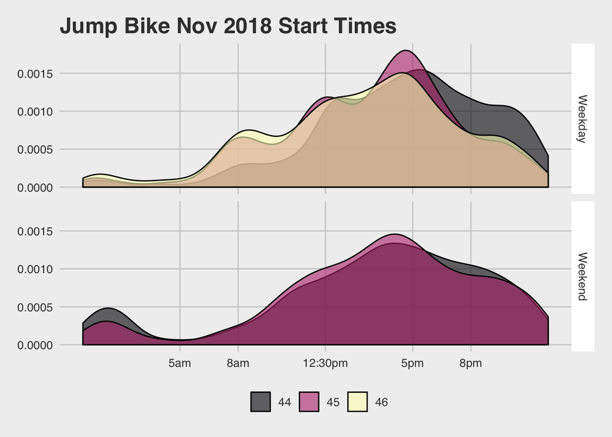

```r
#view start times by weekend/weekday
ggplot(nov_jump, aes(x= mm, fill = week)) +
  geom_density(alpha=.6) +
  scale_x_continuous(labels = c("5am","8am","12:30pm","5pm","8pm"),
                     breaks = c(300,480,750,1020,1200)) +
  labs(fill="",title="Jump Bike Nov 2018 Start Times") +
  theme_fivethirtyeight() +
  theme(strip.background = element_rect(fill = "#FFFFFF")) +
  facet_grid(vars(start_day_type)) +
  scale_fill_viridis_d(option="A")
```

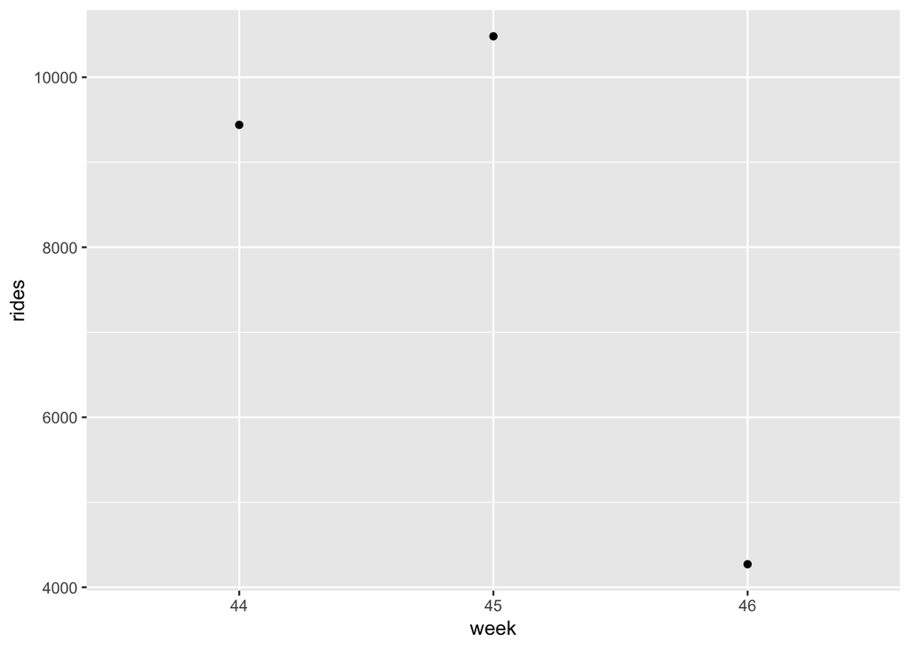

```r
#get freq per week
by_week <- nov_jump %>%
  group_by(week) %>%
  summarise(rides = length(eventType))

#plot it
ggplot(by_week) +
  geom_point(aes(x = week, y = rides))
```

```r
#get freq per day for each week

nov_jump %>%
  group_by(week) %>%
  filter(week == "44") %>%
  select("start_day") %>%
  group_by(start_day) %>%
  summarise(rides = length(week))
```

```
## # A tibble: 4 x 2
##   start_day rides
##   <ord>     <int>
## 1 Thursday   1529
## 2 Friday     2785
## 3 Saturday   2733
## 4 Sunday     2393
```

```r
nov_jump %>%
  group_by(week) %>%
  filter(week == "45") %>%
  select("start_day") %>%
  group_by(start_day) %>%
  summarise(rides = length(week))
```

```
## # A tibble: 6 x 2
##   start_day rides
##   <ord>     <int>
## 1 Monday     1931
## 2 Tuesday    2274
## 3 Wednesday  1721
## 4 Friday     1238
## 5 Saturday   1749
## 6 Sunday     1569
```

```r
nov_jump %>%
  group_by(week) %>%
  filter(week == "46") %>%
  select("start_day") %>%
  group_by(start_day) %>%
  summarise(rides = length(week))
```

```
## # A tibble: 4 x 2
##   start_day rides
##   <ord>     <int>
## 1 Monday     1437
## 2 Tuesday    1598
## 3 Wednesday     2
## 4 Thursday   1234
```

```r
# we are missing days of data the 8th and the 14th :(

#check projection for the start_sf and the jump_tracts
st_crs(start_sf)
```

```
## Coordinate Reference System:
##   EPSG: 4326
##   proj4string: "+proj=longlat +datum=WGS84 +no_defs"
```

```r
st_crs(jump_tracts)
```

```
## Coordinate Reference System:
##   EPSG: 4269
##   proj4string: "+proj=longlat +datum=NAD83 +no_defs"
```

```r
#make them the same for joining
jump_tracts <- st_transform(jump_tracts, crs = 4326)

#join together (spatial join)
start_sf <- st_join(start_sf, jump_tracts,
                    suffix = c(".start", ".start"), left = TRUE)
```

```
## although coordinates are longitude/latitude, st_intersects assumes that they are planar
```

```r
#merge tract census data with jump bike data
nov_jump <- merge(nov_jump, start_sf,
                  by.x = "start_long",
                  by.y = "lon",
                  suffix = c(".start", ".start"),
                  all.x = TRUE)

#this code gets a pretty map for using ggmap
#sac <- get_map(location = c(left= min(start_coord$lon),
 #                           bottom = min(start_coord$lat),
  #                          right = max(start_coord$lon),
   #                         top = max(start_coord$lat)),
    #           source = "stamen",
     #          maptype = "terrain",
      #         zoom = 13)

#get ride counts in tracts
ride_in_tract <- st_join(start_sf, jump_tracts, join = st_within)
```

```
## although coordinates are longitude/latitude, st_within assumes that they are planar
```

```r
ride_count <- count(as_tibble(ride_in_tract), GEOID.x) %>%
  rename(GEOID = GEOID.x, start_count = n) %>%
  print()
```

```
## # A tibble: 103 x 2
##    GEOID       start_count
##    <chr>             <int>
##  1 06067000100          25
##  2 06067000200          79
##  3 06067000300         153
##  4 06067000400         580
##  5 06067000500         855
##  6 06067000600         354
##  7 06067000700        2365
##  8 06067000800         732
##  9 06067001101        5610
## 10 06067001200        1837
## # … with 93 more rows
```

```r
#merge counts
jump_tracts <- left_join(jump_tracts, ride_count)
```

## D3

# Do jump bike origins and destinations happen in socio-economic enclaves in Sacramento?

Need origin / point data and census data for sacramento: need to decide which SES variable from census -> attach to point data

## Autocorrelation

Are there clusters in the Jump bike use? Are they located in enclaves?

## Origin / Destination point access buffers

Who has access to jump bikes?

## Spatial modelling

GWR

# Do jump bike origins / destinations tend towards specific types of land use / zoning?

## Buffers / Zoning

Need to bring in zoning data and understand the zoning, how do we assess the neighbors?

## Modeling? does it make sense ie do zoning types influence jump bike ridership?

# Does weather / timing impact Jump bike ridership?

## Similar to the airplane data

compare ridership to Wind, air quality, temperature, percipitation

## is correlation? Modeling?

# Paper Guidelines

Your final paper should be much the same format as a peer-reviewed journal paper. Typically final papers run 15-18 pages including tables and figures (single-spaced). If you can get everything across in 10 solid pages, that’s great. The general format of the final product should follow this outline:

- Brief introduction and overview of the literature you have reviewed. I do not expect you to have a deep knowledge of the literature, but you should have identified some driving questions that emerge from the literature. State your objectives/hypotheses clearly at the end of the introduction/lit review
- Methods. Give a clear and detailed summary of your data and methods
- Results. Describe your results. Make sure sure you label all tables and figures.
- Conclusion and discussion. Provide a summary of what you have learned about your research question along with the EDA/statistical results that support your conclusions. Also critique your own methods and provide suggestions for improving your analysis. Issues pertaining to the reliability and validity of your data, and appropriateness of the analysis approach should be discussed here. A paragraph on what you would do differently if you were able to start over with the project or what you would do next if you were going to continue work on the project should also be included.